# Analysis of Hawaii Endophyte data

## load specificity package

```r
  library("specificity")
```

## load endophytes data

The endophyte data set is included with our `specificity` package. `attach()` just lets us use the 3 objects within endophyte without writing `endophyte$` every time.

```r
  attach(endophyte)
  names(endophyte)
```

```
## [1] "otutable"  "metadata"  "supertree"
```

- `metadata` is a table of geographic and host information for each sample. Row names correspond to samples.
- `otutable` is a site-by-species matrix. Rows are samples (matching `metadata`), columns are species identities, and values are then number of times a species (OTU) was observed within a sample.
- `supertree` is a phylogenetic tree containing all the host species in `metadata$PlantGenus`.

## get rid of species that are observed too infrequently to analyze.

```r
  dim(otutable)
```

```
## [1]  760 3479
```

```r
  otutable <- prop_abund(otutable)
  otutable_over10 <- occ_threshold(otutable, threshold = 10)
```

## create geographic distance matrix

To create a geographic distance matrix, we use the `rdist.earth` function from the `fields` package. Actually, scratch that. I wrote a wrapper function and included it in the package.

```r
  geo_distmat <- distcalc(metadata$Lat, metadata$Lon, rownames(metadata))
```

## run various specificity analyses

First, we make an empty list object to store specificity results for each variable analyzed.

```r
  specs_list <- list()
  nc <- 20
```

The following variables are just column vectors from `metadata`.

```r
  specs_list$NDVI <- phy_or_env_spec(otutable_over10, env=metadata$NDVI,
    n_cores=nc, denom_type="index_fast")
```

```
## Checking inputs...
```

```
## ...Converting env vector to dist...
```

```
## ...done (took 0 seconds)
```

```
## Calculating emp RAO...
```

```
## ...done (took 0.1 seconds)
```

```
## Calculating sim RAO...
```

```
## ...done (took 17.3 seconds)
```

```
## Calculating and adjusting P-values...
```

```
## ...done (took 0 seconds)
```

```
## ...Calculating sim RAO centers
```

```
## ...Approximating max RAO values (fast)
```

```
## ......1/3: Naive approximation
```

```
## ......2/3: Gen. alg. subset
```

```
## ......3/3: Linear model and predict
```

```
## .........Rsquared=0.998981872727634
```

```
## ...done (took 36.3 seconds)
```

```
## Building output...
```

```
## ...done (took 0 seconds)
```

```r
  specs_list$Elevation <- phy_or_env_spec(otutable_over10, env=metadata$Elevation,
    n_cores=nc, denom_type="index_fast")
```

```
## Checking inputs...
```

```
## ...Converting env vector to dist...
```

```
## ...done (took 0 seconds)
```

```
## Calculating emp RAO...
```

```
## ...done (took 0.1 seconds)
```

```
## Calculating sim RAO...
```

```
## ...done (took 17.3 seconds)
```

```
## Calculating and adjusting P-values...
```

```
## ...done (took 0 seconds)
```

```
## ...Calculating sim RAO centers
```

```
## ...Approximating max RAO values (fast)
```

```
## ......1/3: Naive approximation
```

```
## ......2/3: Gen. alg. subset
```

```
## ......3/3: Linear model and predict
```

```
## .........Rsquared=0.998800086520663
```

```
## ...done (took 1.7 minutes)
```

```
## Building output...
```

```
## ...done (took 0 seconds)
```

```r
  specs_list$Evapotranspiration <- phy_or_env_spec(otutable_over10,
    env=metadata$Evapotranspiration, n_cores=nc, denom_type="index_fast")
```

```
## Checking inputs...
```

```
## ...Converting env vector to dist...
```

```
## ...done (took 0 seconds)
```

```
## Calculating emp RAO...
```

```
## ...done (took 0.1 seconds)
```

```
## Calculating sim RAO...
```

```
## ...done (took 17.3 seconds)
```

```
## Calculating and adjusting P-values...
```

```
## ...done (took 0.1 seconds)
```

```
## ...Calculating sim RAO centers
```

```
## ...Approximating max RAO values (fast)
```

```
## ......1/3: Naive approximation
```

```
## ......2/3: Gen. alg. subset
```

```
## ......3/3: Linear model and predict
```

```
## .........Rsquared=0.998887448142225
```

```
## ...done (took 1.5 minutes)
```

```
## Building output...
```

```
## ...done (took 0 seconds)
```

```r
  specs_list$Rainfall <- phy_or_env_spec(otutable_over10, env=metadata$Rainfall,
    n_cores=nc, denom_type="index_fast")
```

```
## Checking inputs...
```

```
## ...Converting env vector to dist...
```

```
## ...done (took 0 seconds)
```

```
## Calculating emp RAO...
```

```
## ...done (took 0.1 seconds)
```

```
## Calculating sim RAO...
```

```
## ...done (took 17.3 seconds)
```

```
## Calculating and adjusting P-values...
```

```
## ...done (took 0 seconds)
```

```
## ...Calculating sim RAO centers
```

```
## ...Approximating max RAO values (fast)
```

```
## ......1/3: Naive approximation
```

```
## ......2/3: Gen. alg. subset
```

```
## ......3/3: Linear model and predict
```

```
## .........Rsquared=0.999255182191966
```

```
## ...done (took 1.7 minutes)
```

```
## Building output...
```

```
## ...done (took 0 seconds)
```

We can also analyze host specificity, using host phylogenetic entropy.

```r
  specs_list$Host <- phy_or_env_spec(otutable_over10, hosts=metadata$PlantGenus,
    hosts_phylo=supertree, n_cores=nc, denom_type="index_fast")
```

```
## Checking inputs...
```

```
## ...Converting tree to dist...
```

```
## ...done (took 18.5 seconds)
```

```
## Calculating emp RAO...
```

```
## ...done (took 0.1 seconds)
```

```
## Calculating sim RAO...
```

```
## ...done (took 17.3 seconds)
```

```
## Calculating and adjusting P-values...
```

```
## ...done (took 0.1 seconds)
```

```
## ...Calculating sim RAO centers
```

```
## ...Approximating max RAO values (fast)
```

```
## ......1/3: Naive approximation
```

```
## ......2/3: Gen. alg. subset
```

```
## ......3/3: Linear model and predict
```

```
## .........Rsquared=0.999984530687107
```

```
## ...done (took 1.3 minutes)
```

```
## Building output...
```

```
## ...done (took 0 seconds)
```

And we can analyze specificity to geographic location as well.

```r
  specs_list$Geography <- phy_or_env_spec(otutable_over10, env=geo_distmat,
    n_cores=nc, denom_type="index_fast")
```

```
## Checking inputs...
```

```
## ...done (took 0 seconds)
```

```
## Calculating emp RAO...
```

```
## ...done (took 0.1 seconds)
```

```
## Calculating sim RAO...
```

```
## ...done (took 17.3 seconds)
```

```
## Calculating and adjusting P-values...
```

```
## ...done (took 0.1 seconds)
```

```
## ...Calculating sim RAO centers
```

```
## ...Approximating max RAO values (fast)
```

```
## ......1/3: Naive approximation
```

```
## ......2/3: Gen. alg. subset
```

```
## ......3/3: Linear model and predict
```

```
## .........Rsquared=0.998703887471136
```

```
## ...done (took 1.7 minutes)
```

```
## Building output...
```

```
## ...done (took 0 seconds)
```

## save specificity results

```r
  save(list="specs_list", file="specs_results.rdata")
```

## visualizing aggregate specificity trends

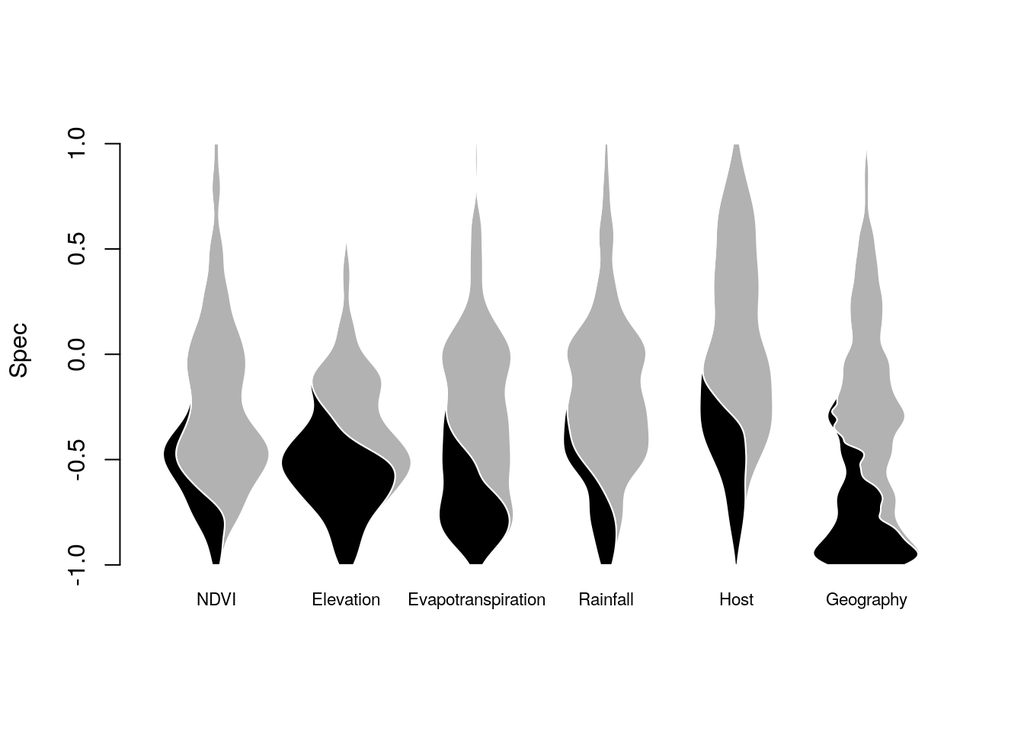

```r
  plot_specs_violin(specs_list, label_cex=0.7)
```

```r
  pdf("specs.pdf")
  plot_specs_violin(specs_list, label_cex=0.7)
  dev.off()
```

## Co-correlation between specificities

```r
  pdf("pairwise_specs.pdf")
  plot_pairwise_spec(specs_list)
  dev.off()
```